# ESEM and CFA Comparison in Measurement Invariance

Mo’men Mohamed

March 15, 2019

**Plz Feel Free to messege me for any advice or recommendations at vet.m.mohamed@gmail.com**

Loading the important package

```r
library(lavaan) ; library(GPArotation) ; library(knitr) ; library(knitLatex) ; library(readxl) ; library(ggplot2) ;library(tidyr) ; library(dplyr) ; library(magrittr) ; library(car) ; library(psych) ; library(kableExtra) ; library(semPlot) ; library(semTools)
```

Reading the data and importing it

```r
big<-read_excel(path = "./data sets/big5.xlsx")
```

Looking at the data structure

```r
str(big)
```

```
## Classes 'tbl_df', 'tbl' and 'data.frame':    225 obs. of  33 variables:
##  $ serial: num  1 2 3 4 5 6 7 8 9 10 ...
##  $ Age   : num  18 19 18 19 18 22 22 18 23 19 ...
##  $ Sex   : num  1 1 1 1 1 1 1 1 1 1 ...
##  $ E1    : num  3 3 3 2 2 4 1 2 3 2 ...
##  $ E2    : num  3 2 4 3 3 4 4 4 3 1 ...
##  $ E3    : num  2 4 3 2 2 4 4 3 3 2 ...
##  $ E4    : num  3 2 4 2 3 4 4 4 3 4 ...
##  $ E6    : num  4 4 1 3 3 4 1 4 3 2 ...
##  $ E7    : num  3 3 4 3 3 4 4 2 2 4 ...
##  $ N1    : num  2 2 4 4 3 2 4 1 2 2 ...
##  $ N2    : num  1 2 1 2 2 3 2 1 2 1 ...
##  $ N3    : num  1 2 2 2 2 2 1 1 2 1 ...
##  $ N5    : num  3 2 1 2 4 3 4 1 3 4 ...
##  $ N8    : num  4 2 1 2 2 3 4 1 2 2 ...
```

[output cut: 19 more lines]

We need to remove “serial” and convert “sex” to factor Male and female

```r
big<-big[,-1]

big$Sex<-factor(x = big$Sex,levels = c(1,2),labels = c("male","female"))

kable(head(big),format = "markdown")
```

| Age | Sex | E1 | E2 | E3 | E4 | E6 | E7 | N1 | N2 | N3 | N5 | N8 | N9 | A1 | A2 | A3 | A4 | A5 | A6 | O2 | O3 | O4 | O5 | O6 | O8 | C3 | C4 | C5 | C6 | … |
| --- | --- | --- | --- | --- | --- | --- | --- | --- | --- | --- | --- | --- | --- | --- | --- | --- | --- | --- | --- | --- | --- | --- | --- | --- | --- | --- | --- | --- | --- | --- |
| 18 | male | 3 | 3 | 2 | 3 | 4 | 3 | 2 | 1 | 1 | 3 | 4 | 1 | 3 | 3 | 4 | 3 | 3 | 3 | 3 | 3 | 1 | 2 | 3 | 4 | 4 | 2 | 3 | 4 | … |
| 19 | male | 3 | 2 | 4 | 2 | 4 | 3 | 2 | 2 | 2 | 2 | 2 | 2 | 3 | 3 | 2 | 3 | 2 | 3 | 2 | 1 | 2 | 3 | 4 | 3 | 2 | 4 | 3 | 2 | … |
| 18 | male | 3 | 4 | 3 | 4 | 1 | 4 | 4 | 1 | 2 | 1 | 1 | 2 | 4 | 2 | 3 | 3 | 3 | 3 | 4 | 3 | 4 | 4 | 3 | 3 | 4 | 4 | 2 | 3 | … |
| 19 | male | 2 | 3 | 2 | 2 | 3 | 3 | 4 | 2 | 2 | 2 | 2 | 2 | 3 | 4 | 4 | 4 | 4 | 4 | 3 | 1 | 3 | 3 | 3 | 3 | 3 | 3 | 3 | 2 | … |
| 18 | male | 2 | 3 | 2 | 3 | 3 | 3 | 3 | 2 | 2 | 4 | 2 | 1 | 3 | 2 | 3 | 4 | 4 | 2 | 4 | 2 | 3 | 4 | 3 | 4 | 2 | 4 | 4 | 3 | … |
| 22 | male | 4 | 4 | 4 | 4 | 4 | 4 | 2 | 3 | 2 | 3 | 3 | 2 | 4 | 4 | 3 | 4 | 4 | 4 | 3 | 2 | 4 | 3 | 3 | 4 | 3 | 4 | 4 | 4 | … |

Now lets look at some summary for the data over all

```r
summary(big) #Foor accurecy, out bound items and missing data
```

```
##       Age            Sex            E1              E2
##  Min.   :17.00   male  :114   Min.   :1.000   Min.   :1.000
##  1st Qu.:18.00   female:111   1st Qu.:2.000   1st Qu.:2.000
##  Median :19.00                Median :2.000   Median :3.000
##  Mean   :20.21                Mean   :2.551   Mean   :2.538
##  3rd Qu.:20.00                3rd Qu.:3.000   3rd Qu.:3.000
##  Max.   :40.00                Max.   :4.000   Max.   :4.000
##        E3              E4              E6              E7
##  Min.   :1.000   Min.   :1.000   Min.   :1.000   Min.   :1.000
##  1st Qu.:2.000   1st Qu.:2.000   1st Qu.:3.000   1st Qu.:2.000
##  Median :2.000   Median :3.000   Median :3.000   Median :3.000
##  Mean   :2.569   Mean   :2.667   Mean   :3.196   Mean   :2.889
##  3rd Qu.:3.000   3rd Qu.:3.000   3rd Qu.:4.000   3rd Qu.:4.000
##  Max.   :4.000   Max.   :4.000   Max.   :4.000   Max.   :4.000
##        N1              N2              N3             N5
##  Min.   :1.000   Min.   :1.000   Min.   :1.00   Min.   :1.000
##  1st Qu.:2.000   1st Qu.:1.000   1st Qu.:1.00   1st Qu.:2.000
##  Median :2.000   Median :2.000   Median :2.00   Median :2.000
##  Mean   :2.356   Mean   :1.942   Mean   :1.96   Mean   :2.302
##  3rd Qu.:3.000   3rd Qu.:2.000   3rd Qu.:2.00   3rd Qu.:3.000
##  Max.   :4.000   Max.   :4.000   Max.   :4.00   Max.   :4.000
##        N8              N9              A1              A2
##  Min.   :1.000   Min.   :1.000   Min.   :1.000   Min.   :1.000
##  1st Qu.:1.000   1st Qu.:1.000   1st Qu.:3.000   1st Qu.:2.000
##  Median :2.000   Median :2.000   Median :4.000   Median :3.000
##  Mean   :2.013   Mean   :1.973   Mean   :3.293   Mean   :2.893
##  3rd Qu.:3.000   3rd Qu.:2.000   3rd Qu.:4.000   3rd Qu.:4.000
##  Max.   :4.000   Max.   :4.000   Max.   :4.000   Max.   :4.000
##        A3              A4              A5              A6
##  Min.   :1.000   Min.   :1.000   Min.   :1.000   Min.   :1.000
##  1st Qu.:2.000   1st Qu.:3.000   1st Qu.:3.000   1st Qu.:2.000
##  Median :3.000   Median :4.000   Median :3.000   Median :3.000
##  Mean   :3.142   Mean   :3.493   Mean   :3.342   Mean   :3.138
##  3rd Qu.:4.000   3rd Qu.:4.000   3rd Qu.:4.000   3rd Qu.:4.000
##  Max.   :4.000   Max.   :4.000   Max.   :4.000   Max.   :4.000
##        O2              O3              O4              O5
##  Min.   :1.000   Min.   :1.000   Min.   :1.000   Min.   :1.000
##  1st Qu.:2.000   1st Qu.:2.000   1st Qu.:2.000   1st Qu.:2.000
##  Median :3.000   Median :3.000   Median :3.000   Median :3.000
##  Mean   :2.769   Mean   :2.533   Mean   :2.693   Mean   :3.062
##  3rd Qu.:4.000   3rd Qu.:3.000   3rd Qu.:4.000   3rd Qu.:4.000
##  Max.   :4.000   Max.   :4.000   Max.   :4.000   Max.   :4.000
##        O6             O8              C3              C4
##  Min.   :1.00   Min.   :1.000   Min.   :1.000   Min.   :1.000
##  1st Qu.:2.00   1st Qu.:3.000   1st Qu.:2.000   1st Qu.:2.000
##  Median :3.00   Median :4.000   Median :3.000   Median :3.000
##  Mean   :2.88   Mean   :3.338   Mean   :2.782   Mean   :3.071
##  3rd Qu.:4.00   3rd Qu.:4.000   3rd Qu.:4.000   3rd Qu.:4.000
##  Max.   :4.00   Max.   :4.000   Max.   :4.000   Max.   :4.000
##        C5             C6              C7             C8
##  Min.   :1.00   Min.   :1.000   Min.   :1.00   Min.   :1.000
##  1st Qu.:2.00   1st Qu.:2.000   1st Qu.:2.00   1st Qu.:3.000
##  Median :3.00   Median :3.000   Median :3.00   Median :3.000
##  Mean   :3.04   Mean   :2.844   Mean   :2.84   Mean   :2.973
##  3rd Qu.:4.00   3rd Qu.:4.000   3rd Qu.:4.00   3rd Qu.:4.000
##  Max.   :4.00   Max.   :4.000   Max.   :4.00   Max.   :4.000
```

Great , the there is no out of bound items or missing data , and the number of males and females is all most equal

The normality and linearity assumption is critical for Factor analysis and SEM , So, Lets test it

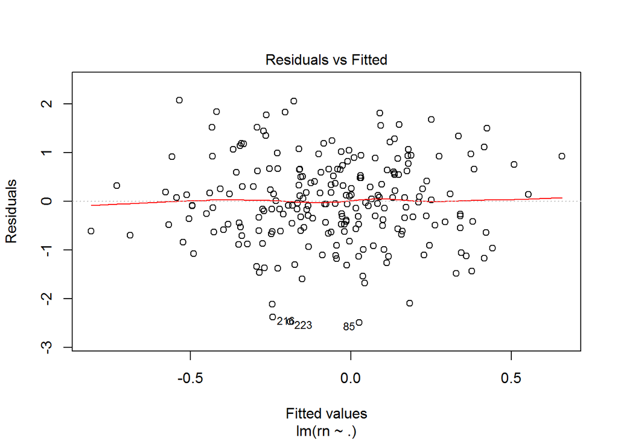

```r
#Testing Multivariate Normality using QQplot From fake regression on random normal variable
set.seed(0124)
rn<-rnorm(n = nrow(big))
lm<-lm(rn~.,data = big[,-c(1,2)])

plot(lm,1) #Homogeniety
```

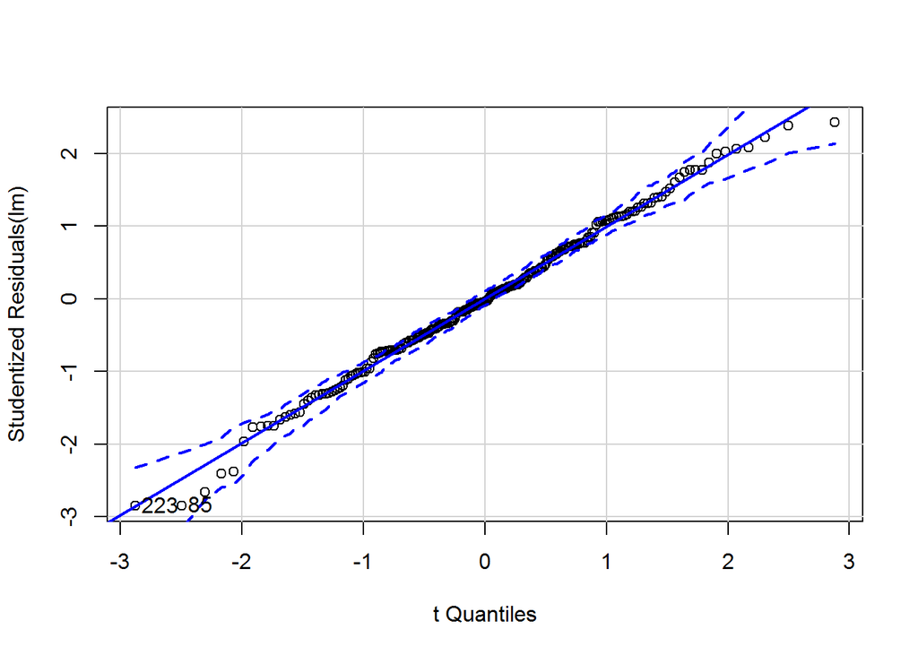

```
## [1]  85 223
```

```r
qqPlot(lm) # Normality and linearity
```

From The QQplot we can see that we can assume the normality and linearity of the data !!

The following steps include conducting EFA

Lets start :

Firstly lets test the assumptions : **Additivity** , **sample adequacy**

```r
#Additivity

corr<-cor(x = big[,-c(1,2)],method = "p")

kable(corr,digits = 2,format = "markdown") #correlation table
```

|  | E1 | E2 | E3 | E4 | E6 | E7 | N1 | N2 | N3 | N5 | N8 | N9 | A1 | A2 | A3 | A4 | A5 | A6 | O2 | O3 | O4 | O5 | O6 | O8 | C3 | C4 | C5 | C6 | C7 | … |
| --- | --- | --- | --- | --- | --- | --- | --- | --- | --- | --- | --- | --- | --- | --- | --- | --- | --- | --- | --- | --- | --- | --- | --- | --- | --- | --- | --- | --- | --- | --- |
| E1 | 1.00 | 0.39 | 0.55 | 0.43 | 0.44 | 0.35 | -0.11 | -0.07 | -0.21 | -0.17 | -0.02 | -0.21 | 0.03 | 0.09 | 0.08 | 0.11 | 0.18 | 0.18 | 0.08 | 0.05 | 0.03 | 0.14 | 0.11 | 0.24 | 0.10 | 0.16 | 0.18 | 0.05 | 0.10 | … |
| E2 | 0.39 | 1.00 | 0.44 | 0.26 | 0.32 | 0.39 | -0.09 | -0.18 | -0.24 | -0.12 | -0.02 | -0.25 | 0.05 | 0.07 | 0.10 | 0.13 | 0.22 | 0.18 | 0.12 | 0.06 | 0.18 | 0.06 | 0.11 | 0.32 | 0.06 | 0.12 | 0.24 | 0.02 | 0.09 | … |
| E3 | 0.55 | 0.44 | 1.00 | 0.35 | 0.42 | 0.47 | -0.12 | -0.19 | -0.32 | -0.13 | -0.06 | -0.24 | 0.10 | 0.06 | 0.05 | 0.12 | 0.24 | 0.18 | 0.16 | 0.14 | 0.22 | 0.20 | 0.20 | 0.26 | 0.23 | 0.23 | 0.18 | 0.14 | 0.25 | … |
| E4 | 0.43 | 0.26 | 0.35 | 1.00 | 0.27 | 0.39 | -0.08 | -0.11 | -0.20 | -0.02 | 0.01 | -0.11 | 0.00 | 0.13 | 0.13 | 0.17 | 0.24 | 0.21 | 0.13 | 0.11 | 0.17 | 0.18 | 0.13 | 0.18 | 0.09 | 0.22 | 0.11 | 0.03 | 0.07 | … |
| E6 | 0.44 | 0.32 | 0.42 | 0.27 | 1.00 | 0.35 | -0.15 | -0.29 | -0.44 | -0.33 | -0.15 | -0.49 | -0.04 | 0.09 | -0.02 | 0.09 | 0.08 | 0.09 | -0.08 | 0.05 | -0.03 | 0.09 | 0.09 | 0.16 | 0.02 | 0.07 | 0.16 | 0.08 | 0.05 | … |
| E7 | 0.35 | 0.39 | 0.47 | 0.39 | 0.35 | 1.00 | -0.05 | -0.20 | -0.31 | -0.13 | -0.03 | -0.26 | 0.10 | 0.06 | 0.12 | 0.19 | 0.28 | 0.21 | 0.19 | 0.09 | 0.13 | 0.21 | 0.18 | 0.29 | 0.15 | 0.30 | 0.27 | -0.02 | 0.14 | … |
| N1 | -0.11 | -0.09 | -0.12 | -0.08 | -0.15 | -0.05 | 1.00 | 0.41 | 0.35 | 0.49 | 0.33 | 0.16 | 0.02 | 0.06 | 0.00 | 0.04 | 0.05 | 0.01 | -0.10 | 0.01 | -0.11 | -0.10 | -0.11 | 0.03 | -0.04 | -0.12 | -0.10 | -0.14 | -0.10 | … |
| N2 | -0.07 | -0.18 | -0.19 | -0.11 | -0.29 | -0.20 | 0.41 | 1.00 | 0.55 | 0.43 | 0.28 | 0.37 | 0.11 | 0.02 | 0.08 | 0.00 | 0.08 | 0.11 | 0.02 | -0.05 | -0.03 | -0.09 | -0.08 | -0.05 | 0.02 | -0.12 | -0.04 | 0.00 | -0.02 | … |
| N3 | -0.21 | -0.24 | -0.32 | -0.20 | -0.44 | -0.31 | 0.35 | 0.55 | 1.00 | 0.37 | 0.30 | 0.51 | 0.05 | 0.08 | 0.11 | 0.03 | 0.01 | 0.02 | 0.02 | -0.02 | -0.03 | -0.07 | -0.04 | -0.12 | 0.05 | -0.18 | -0.09 | 0.01 | -0.10 | … |
| N5 | -0.17 | -0.12 | -0.13 | -0.02 | -0.33 | -0.13 | 0.49 | 0.43 | 0.37 | 1.00 | 0.52 | 0.36 | -0.03 | -0.03 | 0.03 | -0.03 | 0.01 | -0.07 | -0.14 | -0.02 | -0.03 | -0.16 | -0.14 | -0.02 | -0.01 | -0.11 | -0.11 | -0.11 | -0.09 | … |
| N8 | -0.02 | -0.02 | -0.06 | 0.01 | -0.15 | -0.03 | 0.33 | 0.28 | 0.30 | 0.52 | 1.00 | 0.30 | -0.09 | 0.01 | 0.02 | -0.01 | 0.05 | -0.03 | -0.11 | -0.10 | -0.05 | -0.13 | -0.05 | 0.02 | 0.03 | -0.15 | -0.13 | -0.13 | -0.20 | … |
| N9 | -0.21 | -0.25 | -0.24 | -0.11 | -0.49 | -0.26 | 0.16 | 0.37 | 0.51 | 0.36 | 0.30 | 1.00 | 0.04 | 0.02 | 0.10 | 0.02 | -0.04 | -0.06 | 0.02 | 0.02 | -0.01 | -0.09 | -0.05 | -0.07 | 0.04 | -0.11 | -0.15 | -0.08 | -0.06 | … |
| A1 | 0.03 | 0.05 | 0.10 | 0.00 | -0.04 | 0.10 | 0.02 | 0.11 | 0.05 | -0.03 | -0.09 | 0.04 | 1.00 | 0.34 | 0.41 | 0.38 | 0.36 | 0.39 | 0.14 | 0.23 | 0.21 | 0.17 | 0.01 | 0.19 | 0.22 | 0.17 | 0.16 | 0.33 | 0.34 | … |
| A2 | 0.09 | 0.07 | 0.06 | 0.13 | 0.09 | 0.06 | 0.06 | 0.02 | 0.08 | -0.03 | 0.01 | 0.02 | 0.34 | 1.00 | 0.47 | 0.31 | 0.34 | 0.36 | 0.07 | 0.08 | 0.12 | 0.17 | 0.13 | 0.15 | 0.13 | 0.10 | 0.10 | 0.12 | 0.17 | … |
| A3 | 0.08 | 0.10 | 0.05 | 0.13 | -0.02 | 0.12 | 0.00 | 0.08 | 0.11 | 0.03 | 0.02 | 0.10 | 0.41 | 0.47 | 1.00 | 0.43 | 0.49 | 0.39 | 0.13 | 0.18 | 0.19 | 0.18 | 0.12 | 0.26 | 0.26 | 0.08 | 0.16 | 0.22 | 0.27 | … |
| A4 | 0.11 | 0.13 | 0.12 | 0.17 | 0.09 | 0.19 | 0.04 | 0.00 | 0.03 | -0.03 | -0.01 | 0.02 | 0.38 | 0.31 | 0.43 | 1.00 | 0.54 | 0.41 | 0.08 | 0.18 | 0.22 | 0.24 | 0.16 | 0.24 | 0.18 | 0.18 | 0.22 | 0.18 | 0.26 | … |
| A5 | 0.18 | 0.22 | 0.24 | 0.24 | 0.08 | 0.28 | 0.05 | 0.08 | 0.01 | 0.01 | 0.05 | -0.04 | 0.36 | 0.34 | 0.49 | 0.54 | 1.00 | 0.51 | 0.24 | 0.16 | 0.31 | 0.23 | 0.18 | 0.28 | 0.31 | 0.34 | 0.36 | 0.26 | 0.36 | … |
| A6 | 0.18 | 0.18 | 0.18 | 0.21 | 0.09 | 0.21 | 0.01 | 0.11 | 0.02 | -0.07 | -0.03 | -0.06 | 0.39 | 0.36 | 0.39 | 0.41 | 0.51 | 1.00 | 0.15 | 0.18 | 0.33 | 0.23 | 0.19 | 0.21 | 0.24 | 0.29 | 0.36 | 0.38 | 0.28 | … |
| O2 | 0.08 | 0.12 | 0.16 | 0.13 | -0.08 | 0.19 | -0.10 | 0.02 | 0.02 | -0.14 | -0.11 | 0.02 | 0.14 | 0.07 | 0.13 | 0.08 | 0.24 | 0.15 | 1.00 | 0.39 | 0.49 | 0.48 | 0.35 | 0.10 | 0.30 | 0.31 | 0.27 | 0.21 | 0.30 | … |
| O3 | 0.05 | 0.06 | 0.14 | 0.11 | 0.05 | 0.09 | 0.01 | -0.05 | -0.02 | -0.02 | -0.10 | 0.02 | 0.23 | 0.08 | 0.18 | 0.18 | 0.16 | 0.18 | 0.39 | 1.00 | 0.30 | 0.34 | 0.22 | 0.19 | 0.23 | 0.14 | 0.10 | 0.19 | 0.21 | … |
| O4 | 0.03 | 0.18 | 0.22 | 0.17 | -0.03 | 0.13 | -0.11 | -0.03 | -0.03 | -0.03 | -0.05 | -0.01 | 0.21 | 0.12 | 0.19 | 0.22 | 0.31 | 0.33 | 0.49 | 0.30 | 1.00 | 0.54 | 0.36 | 0.27 | 0.36 | 0.25 | 0.31 | 0.27 | 0.27 | … |
| O5 | 0.14 | 0.06 | 0.20 | 0.18 | 0.09 | 0.21 | -0.10 | -0.09 | -0.07 | -0.16 | -0.13 | -0.09 | 0.17 | 0.17 | 0.18 | 0.24 | 0.23 | 0.23 | 0.48 | 0.34 | 0.54 | 1.00 | 0.36 | 0.30 | 0.24 | 0.25 | 0.29 | 0.20 | 0.30 | … |
| O6 | 0.11 | 0.11 | 0.20 | 0.13 | 0.09 | 0.18 | -0.11 | -0.08 | -0.04 | -0.14 | -0.05 | -0.05 | 0.01 | 0.13 | 0.12 | 0.16 | 0.18 | 0.19 | 0.35 | 0.22 | 0.36 | 0.36 | 1.00 | 0.26 | 0.37 | 0.28 | 0.27 | 0.28 | 0.27 | … |
| O8 | 0.24 | 0.32 | 0.26 | 0.18 | 0.16 | 0.29 | 0.03 | -0.05 | -0.12 | -0.02 | 0.02 | -0.07 | 0.19 | 0.15 | 0.26 | 0.24 | 0.28 | 0.21 | 0.10 | 0.19 | 0.27 | 0.30 | 0.26 | 1.00 | 0.20 | 0.24 | 0.29 | 0.18 | 0.20 | … |
| C3 | 0.10 | 0.06 | 0.23 | 0.09 | 0.02 | 0.15 | -0.04 | 0.02 | 0.05 | -0.01 | 0.03 | 0.04 | 0.22 | 0.13 | 0.26 | 0.18 | 0.31 | 0.24 | 0.30 | 0.23 | 0.36 | 0.24 | 0.37 | 0.20 | 1.00 | 0.39 | 0.37 | 0.48 | 0.47 | … |
| C4 | 0.16 | 0.12 | 0.23 | 0.22 | 0.07 | 0.30 | -0.12 | -0.12 | -0.18 | -0.11 | -0.15 | -0.11 | 0.17 | 0.10 | 0.08 | 0.18 | 0.34 | 0.29 | 0.31 | 0.14 | 0.25 | 0.25 | 0.28 | 0.24 | 0.39 | 1.00 | 0.59 | 0.30 | 0.38 | … |
| C5 | 0.18 | 0.24 | 0.18 | 0.11 | 0.16 | 0.27 | -0.10 | -0.04 | -0.09 | -0.11 | -0.13 | -0.15 | 0.16 | 0.10 | 0.16 | 0.22 | 0.36 | 0.36 | 0.27 | 0.10 | 0.31 | 0.29 | 0.27 | 0.29 | 0.37 | 0.59 | 1.00 | 0.43 | 0.50 | … |
| C6 | 0.05 | 0.02 | 0.14 | 0.03 | 0.08 | -0.02 | -0.14 | 0.00 | 0.01 | -0.11 | -0.13 | -0.08 | 0.33 | 0.12 | 0.22 | 0.18 | 0.26 | 0.38 | 0.21 | 0.19 | 0.27 | 0.20 | 0.28 | 0.18 | 0.48 | 0.30 | 0.43 | 1.00 | 0.66 | … |
| C7 | 0.10 | 0.09 | 0.25 | 0.07 | 0.05 | 0.14 | -0.10 | -0.02 | -0.10 | -0.09 | -0.20 | -0.06 | 0.34 | 0.17 | 0.27 | 0.26 | 0.36 | 0.28 | 0.30 | 0.21 | 0.27 | 0.30 | 0.27 | 0.20 | 0.47 | 0.38 | 0.50 | 0.66 | 1.00 | … |
| C8 | 0.06 | 0.06 | 0.14 | 0.05 | 0.16 | 0.04 | -0.23 | -0.04 | -0.14 | -0.16 | -0.25 | -0.13 | 0.18 | 0.14 | 0.11 | 0.16 | 0.18 | 0.27 | 0.25 | 0.18 | 0.25 | 0.28 | 0.26 | 0.08 | 0.26 | 0.30 | 0.37 | 0.43 | 0.42 | … |

```r
corr%>%apply(MARGIN = 2,function(x){
any(x<1&x>=abs(.9))
}) #Testing if there are a correlation over .9 between the items to avoid multicolinearity
```

```
##    E1    E2    E3    E4    E6    E7    N1    N2    N3    N5    N8    N9
## FALSE FALSE FALSE FALSE FALSE FALSE FALSE FALSE FALSE FALSE FALSE FALSE
##    A1    A2    A3    A4    A5    A6    O2    O3    O4    O5    O6    O8
## FALSE FALSE FALSE FALSE FALSE FALSE FALSE FALSE FALSE FALSE FALSE FALSE
##    C3    C4    C5    C6    C7    C8
## FALSE FALSE FALSE FALSE FALSE FALSE
```

```r
#Enough correlation & Sample adequacy
cortest.bartlett(R = corr,n = nrow(big))$p.value#correlation bartelett test
```

```
## [1] 7.124156e-269
```

```r
KMO(corr)$MSA #Kaiser-Meyer-Olkin test
```

```
## [1] 0.8278375
```

since the assumptions have been met ( sig cor Bartlett and MSA >.8 and no additive ), Now we can run EFA

AS there are a priori theory which assume the presence of 5 factors on which the items load in unique way , there is no need to test the number of factors

but lets do it for fun !!

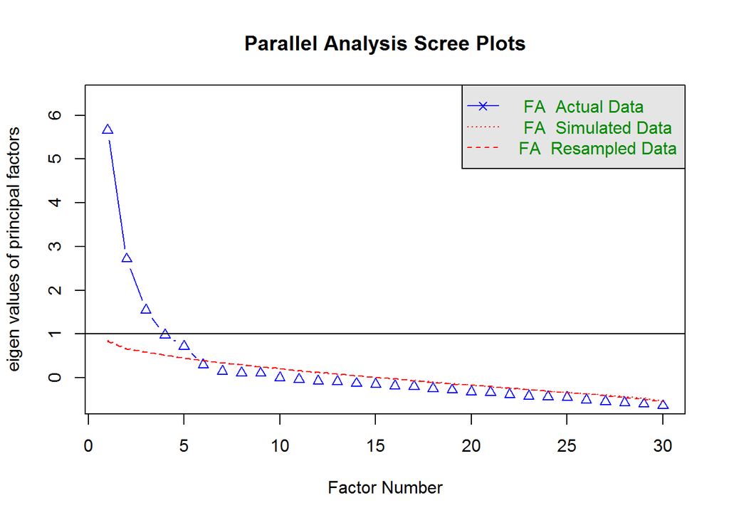

```
## Parallel analysis suggests that the number of factors =  5  and the number of components =  NA
```

```r
facno<-fa.parallel(x = big[,-c(1,2)],fm = "ml",fa = "fa") # as th data is normal , we choosed the Muximum likelihood method of Extraction
```

The parallel test suggest 5 factors !! agreeing with the theory , but for fancy lets look at scree plot & Kaiser Criterion

```r
(facno$fa.values>.7)%>%sum() #Kaiser criterion suggest 5 Factors !!
```

```
## [1] 5
```

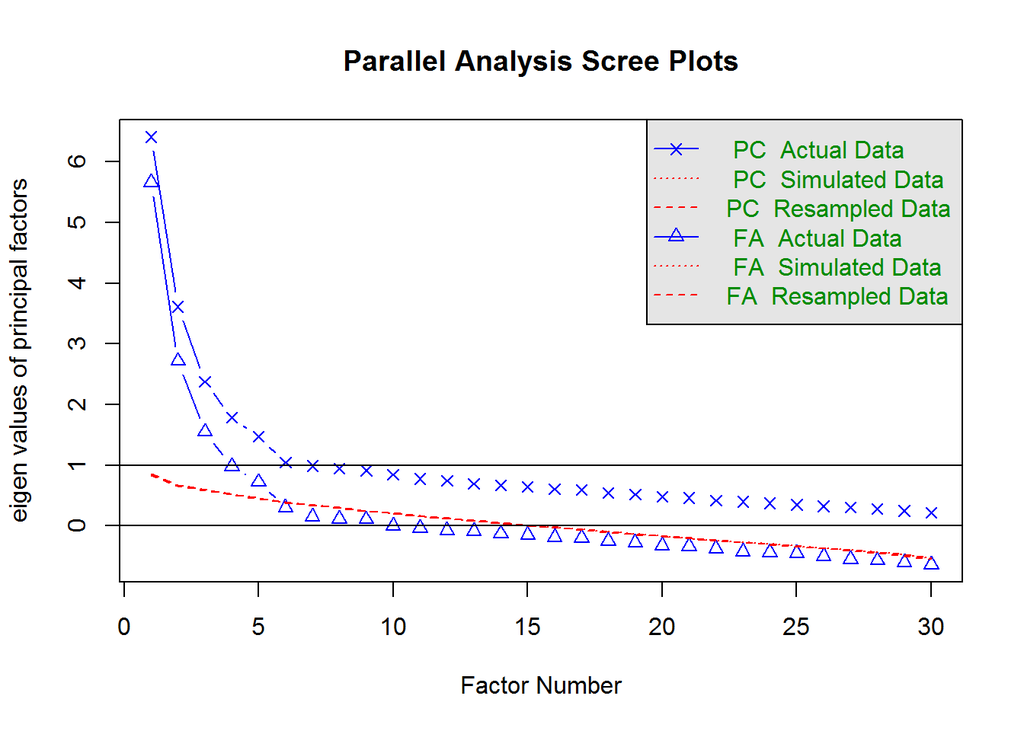

```r
plot(facno) #Scree plot Suggest 4 Factors with almost more one !!
```

As we see that Kaiser criterion of Eigen value suggest 5 factors and scree suggests 4 and almost one !! so we will consider those 5 !!

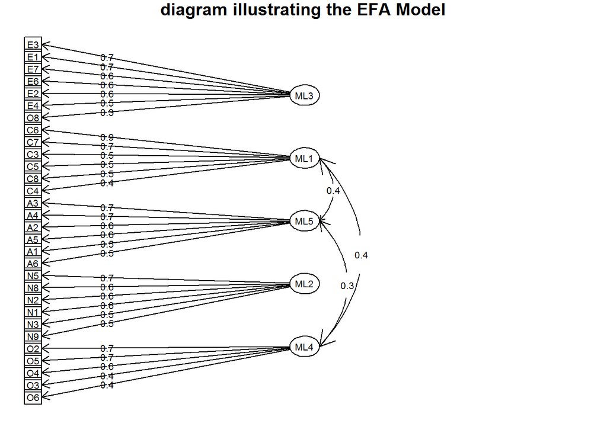

```r
fit<-fa(r = big[,-c(1,2)],nfactors = 5,rotate = "geominQ",fm = "ml")
fa.diagram(fit,main = "diagram illustrating the EFA Model")
```

The theory says that the factors are uncorrelated and it is supposed to use *“Orthogonal”* rotation Neverthless we will use *oblique (oblimin geomin) Rotation* , which allows the factors to correlate and that to match the default rotation method in *M-Plus* for *ESEM* and also since the data is normal , so we used *maximum likelihood* Extraction method

```r
fit$loadings%>%matrix(ncol = 5,dimnames = list(c(names(big[,-c(1,2)])),paste0("F",1:5)))%>%kable(format = "markdown",digits = 3,caption = "Factor Items loading",row.names = T)
```

|  | F1 | F2 | F3 | F4 | F5 |
| --- | --- | --- | --- | --- | --- |
| E1 | 0.659 | 0.023 | 0.019 | 0.007 | -0.067 |
| E2 | 0.570 | -0.042 | 0.069 | -0.029 | 0.016 |
| E3 | 0.684 | 0.122 | -0.056 | -0.003 | 0.053 |
| E4 | 0.501 | -0.100 | 0.106 | 0.039 | 0.111 |
| E6 | 0.588 | 0.037 | 0.022 | -0.315 | -0.221 |
| E7 | 0.622 | -0.076 | 0.086 | -0.033 | 0.113 |
| N1 | 0.018 | -0.059 | 0.037 | 0.554 | -0.096 |
| N2 | -0.193 | 0.093 | 0.049 | 0.591 | -0.027 |
| N3 | -0.402 | 0.019 | 0.084 | 0.548 | 0.070 |
| N5 | -0.017 | 0.029 | -0.100 | 0.735 | -0.064 |
| N8 | 0.127 | -0.092 | -0.053 | 0.625 | -0.055 |
| N9 | -0.365 | -0.045 | 0.035 | 0.461 | 0.141 |
| A1 | -0.110 | 0.182 | 0.547 | -0.031 | -0.036 |
| A2 | -0.015 | -0.070 | 0.611 | -0.044 | -0.029 |
| A3 | -0.053 | -0.005 | 0.714 | 0.020 | -0.001 |
| A4 | 0.064 | -0.024 | 0.656 | -0.026 | 0.015 |
| A5 | 0.200 | 0.110 | 0.587 | 0.106 | 0.054 |
| A6 | 0.111 | 0.196 | 0.524 | 0.020 | 0.002 |
| O2 | -0.048 | 0.059 | -0.060 | -0.006 | 0.730 |
| O3 | -0.024 | 0.024 | 0.108 | -0.023 | 0.415 |
| O4 | 0.009 | 0.066 | 0.081 | 0.023 | 0.643 |
| O5 | 0.028 | -0.018 | 0.104 | -0.116 | 0.652 |
| O6 | 0.093 | 0.205 | -0.053 | -0.013 | 0.405 |
| O8 | 0.318 | 0.061 | 0.183 | 0.065 | 0.149 |
| C3 | 0.066 | 0.534 | -0.014 | 0.166 | 0.188 |
| C4 | 0.212 | 0.389 | -0.018 | -0.021 | 0.187 |
| C5 | 0.203 | 0.531 | 0.015 | 0.009 | 0.097 |
| C6 | -0.084 | 0.860 | 0.031 | -0.020 | -0.104 |
| C7 | 0.013 | 0.750 | 0.075 | -0.023 | 0.006 |
| C8 | -0.035 | 0.456 | 0.034 | -0.195 | 0.107 |

```r
fit$r.scores%>%matrix(nrow = 5,dimnames = list(c(paste0("f",1:5)),c(paste0("f",1:5))))%>%kable(format = "markdown",digits = 3,caption = "factor correlation")
```

|  | f1 | f2 | f3 | f4 | f5 |
| --- | --- | --- | --- | --- | --- |
| f1 | 1.000 | 0.211 | 0.247 | -0.222 | 0.286 |
| f2 | 0.211 | 1.000 | 0.477 | -0.149 | 0.522 |
| f3 | 0.247 | 0.477 | 1.000 | 0.152 | 0.395 |
| f4 | -0.222 | -0.149 | 0.152 | 1.000 | -0.062 |
| f5 | 0.286 | 0.522 | 0.395 | -0.062 | 1.000 |

at the tables above we see the factor-items loadings and factors correlations

we need to know if there are any significant cross loading of any of the items

```r
load<-fit$loadings%>%matrix(ncol = 5,dimnames = list(c(names(big[,-c(1,2)])),paste0("F",1:5)))%>%round(digits = 3)

load%>%apply(MARGIN = 2,FUN = function(x){
ifelse(test = x>=.3,yes = x,no = paste("-"))
})%>%matrix(ncol = 5,dimnames =list(c(names(big[,-c(1,2)])),paste0("F",1:5)))%>%kable(format = "markdown",digits = 3)
```

|  | F1 | F2 | F3 | F4 | F5 |
| --- | --- | --- | --- | --- | --- |
| E1 | 0.659 | - | - | - | - |
| E2 | 0.57 | - | - | - | - |
| E3 | 0.684 | - | - | - | - |
| E4 | 0.501 | - | - | - | - |
| E6 | 0.588 | - | - | - | - |
| E7 | 0.622 | - | - | - | - |
| N1 | - | - | - | 0.554 | - |
| N2 | - | - | - | 0.591 | - |
| N3 | - | - | - | 0.548 | - |
| N5 | - | - | - | 0.735 | - |
| N8 | - | - | - | 0.625 | - |
| N9 | - | - | - | 0.461 | - |
| A1 | - | - | 0.547 | - | - |
| A2 | - | - | 0.611 | - | - |
| A3 | - | - | 0.714 | - | - |
| A4 | - | - | 0.656 | - | - |
| A5 | - | - | 0.587 | - | - |
| A6 | - | - | 0.524 | - | - |
| O2 | - | - | - | - | 0.73 |
| O3 | - | - | - | - | 0.415 |
| O4 | - | - | - | - | 0.643 |
| O5 | - | - | - | - | 0.652 |
| O6 | - | - | - | - | 0.405 |
| O8 | 0.318 | - | - | - | - |
| C3 | - | 0.534 | - | - | - |
| C4 | - | 0.389 | - | - | - |
| C5 | - | 0.531 | - | - | - |
| C6 | - | 0.86 | - | - | - |
| C7 | - | 0.75 | - | - | - |
| C8 | - | 0.456 | - | - | - |

in the loading detection table we see that item O8 which is supposed to load on to factor 5 , loads on factor 1

here i feel free to delete this item especially as we have another 5 items in its factor

```r
big<-big%>%select(-O8)
```

and then run EFA again

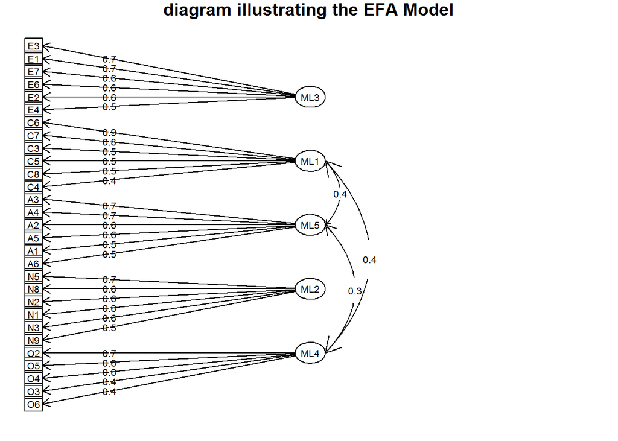

```r
fit<-fa(r = big[,-c(1,2)],nfactors = 5,rotate = "geominQ",fm = "ml")
fa.diagram(fit,main = "diagram illustrating the EFA Model")
```

```r
load<-fit$loadings%>%matrix(ncol = 5,dimnames = list(c(names(big[,-c(1,2)])),paste0("F",1:5)))%>%round(digits = 3)

load%>%apply(MARGIN = 2,FUN = function(x){
ifelse(test = x>=.3,yes = x,no = paste("-"))
})%>%matrix(ncol = 5,dimnames =list(c(names(big[,-c(1,2)])),paste0("F",1:5)))%>%kable(format = "markdown",digits = 3)
```

|  | F1 | F2 | F3 | F4 | F5 |
| --- | --- | --- | --- | --- | --- |
| E1 | 0.66 | - | - | - | - |
| E2 | 0.556 | - | - | - | - |
| E3 | 0.686 | - | - | - | - |
| E4 | 0.506 | - | - | - | - |
| E6 | 0.584 | - | - | - | - |
| E7 | 0.617 | - | - | - | - |
| N1 | - | - | - | 0.551 | - |
| N2 | - | - | - | 0.595 | - |
| N3 | - | - | - | 0.551 | - |
| N5 | - | - | - | 0.733 | - |
| N8 | - | - | - | 0.624 | - |
| N9 | - | - | - | 0.462 | - |
| A1 | - | - | 0.542 | - | - |
| A2 | - | - | 0.609 | - | - |
| A3 | - | - | 0.708 | - | - |
| A4 | - | - | 0.659 | - | - |
| A5 | - | - | 0.593 | - | - |
| A6 | - | - | 0.528 | - | - |
| O2 | - | - | - | - | 0.743 |
| O3 | - | - | - | - | 0.413 |
| O4 | - | - | - | - | 0.631 |
| O5 | - | - | - | - | 0.638 |
| O6 | - | - | - | - | 0.399 |
| C3 | - | 0.538 | - | - | - |
| C4 | - | 0.387 | - | - | - |
| C5 | - | 0.532 | - | - | - |
| C6 | - | 0.865 | - | - | - |
| C7 | - | 0.75 | - | - | - |
| C8 | - | 0.454 | - | - | - |

Now it is awesome , we have here a great factors structure

So, lets test the reliability of each dimension using alpha

```r
F1<-big%>%select(E1,E2,E3,E4,E6,E7)
F2<-big%>%select(N1,N2,N3,N5,N8,N9)
F3<-big%>%select(A1,A2,A3,A4,A5,A6)
F4<-big%>%select(O2,O3,O4,O5,O6)
F5<-big%>%select(C3,C4,C5,C6,C7,C8)

dimenstions<-list(F1,F2,F3,F4,F5)

alphas<-data.frame(test=psych::alpha(check.keys = T,big%>%select(-c(Age,Sex)))$total[1],
                   F1=psych::alpha(F1)$total[1],
                   F2=psych::alpha(F2)$total[1],
                   F3=psych::alpha(F3)$total[1],
                   F4=psych::alpha(F4)$total[1],
                   F5=psych::alpha(F5)$total[1])

names(alphas)<-c("All test",paste("F",1:5))
alphas%>%kable(format = "markdown",digits = 2) # table contain row alpha for the all items and every factor
```

| All test | F 1 | F 2 | F 3 | F 4 | F 5 |
| --- | --- | --- | --- | --- | --- |
| 0.86 | 0.79 | 0.78 | 0.8 | 0.75 | 0.81 |

here the alpha values of each factor is roughly good , so we can claim here that the dimensions is reliable

After finishing the EFA lets start in CFA and Confirming the structure of the model

First of all we have to specify the model

```r
bigmodel<-"
f1=~E1+E2+E3+E4+E6+E7
f2=~N1+N2+N3+N5+N8+N9
f3=~A1+A2+A3+A4+A5+A6
f4=~O2+O3+O4+O5+O6
f5=~C3+C4+C5+C6+C7+C8
"
```

After specifying the model we will use `cfa()` function to run the model

```r
bigfit<-cfa(model = bigmodel,data = big%>%select(-c(Age,Sex)))

summary(bigfit,standardized=T,fit.measures=T)
```

```
## lavaan 0.6-3 ended normally after 54 iterations
##
##   Optimization method                           NLMINB
##   Number of free parameters                         68
##
##   Number of observations                           225
##
##   Estimator                                         ML
##   Model Fit Test Statistic                     632.465
##   Degrees of freedom                               367
##   P-value (Chi-square)                           0.000
##
## Model test baseline model:
##
##   Minimum Function Test Statistic             2448.865
##   Degrees of freedom                               406
##   P-value                                        0.000
##
## User model versus baseline model:
##
##   Comparative Fit Index (CFI)                    0.870
##   Tucker-Lewis Index (TLI)                       0.856
##
## Loglikelihood and Information Criteria:
##
##   Loglikelihood user model (H0)              -7705.204
##   Loglikelihood unrestricted model (H1)      -7388.972
##
##   Number of free parameters                         68
##   Akaike (AIC)                               15546.409
##   Bayesian (BIC)                             15778.703
##   Sample-size adjusted Bayesian (BIC)        15563.198
##
## Root Mean Square Error of Approximation:
##
##   RMSEA                                          0.057
##   90 Percent Confidence Interval          0.049  0.064
##   P-value RMSEA <= 0.05                          0.071
##
## Standardized Root Mean Square Residual:
```

[output cut: 84 more lines]

```
##    .O3                0.785    0.080    9.856    0.000    0.785    0.774
##    .O4                0.470    0.060    7.810    0.000    0.470    0.485
##    .O5                0.365    0.047    7.814    0.000    0.365    0.485
##    .O6                0.645    0.067    9.632    0.000    0.645    0.726
##    .C3                0.581    0.061    9.497    0.000    0.581    0.627
##    .C4                0.564    0.058    9.666    0.000    0.564    0.665
##    .C5                0.455    0.050    9.026    0.000    0.455    0.543
##    .C6                0.425    0.050    8.512    0.000    0.425    0.474
##    .C7                0.295    0.039    7.601    0.000    0.295    0.386
##    .C8                0.564    0.057    9.830    0.000    0.564    0.705
##     f1                0.386    0.072    5.357    0.000    1.000    1.000
##     f2                0.294    0.074    3.968    0.000    1.000    1.000
##     f3                0.213    0.050    4.232    0.000    1.000    1.000
##     f4                0.398    0.076    5.228    0.000    1.000    1.000
##     f5                0.345    0.073    4.711    0.000    1.000    1.000
```

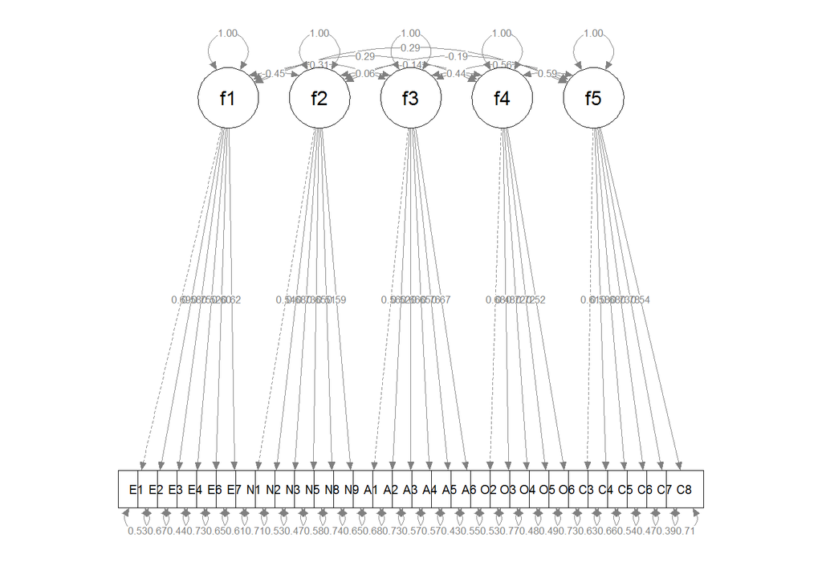

```r
semPaths(bigfit,whatLabels = "std",layout = "tree")
```

The following is the table of all parameters estimated

```r
parameterEstimates(bigfit,standardized = T)%>%kable(digits = 2,format = "markdown")
```

| lhs | op | rhs | est | se | z | pvalue | ci.lower | ci.upper | std.lv | std.all | std.nox |
| --- | --- | --- | --- | --- | --- | --- | --- | --- | --- | --- | --- |
| f1 | =~ | E1 | 1.00 | 0.00 | NA | NA | 1.00 | 1.00 | 0.62 | 0.69 | 0.69 |
| f1 | =~ | E2 | 0.95 | 0.13 | 7.44 | 0.00 | 0.70 | 1.20 | 0.59 | 0.58 | 0.58 |
| f1 | =~ | E3 | 1.18 | 0.13 | 9.19 | 0.00 | 0.93 | 1.44 | 0.74 | 0.75 | 0.75 |
| f1 | =~ | E4 | 0.79 | 0.12 | 6.81 | 0.00 | 0.56 | 1.02 | 0.49 | 0.52 | 0.52 |
| f1 | =~ | E6 | 0.89 | 0.12 | 7.65 | 0.00 | 0.66 | 1.12 | 0.55 | 0.60 | 0.60 |
| f1 | =~ | E7 | 0.89 | 0.11 | 7.96 | 0.00 | 0.67 | 1.11 | 0.55 | 0.62 | 0.62 |
| f2 | =~ | N1 | 1.00 | 0.00 | NA | NA | 1.00 | 1.00 | 0.54 | 0.54 | 0.54 |
| f2 | =~ | N2 | 1.08 | 0.16 | 6.93 | 0.00 | 0.77 | 1.38 | 0.58 | 0.68 | 0.68 |
| f2 | =~ | N3 | 1.15 | 0.16 | 7.16 | 0.00 | 0.84 | 1.47 | 0.63 | 0.73 | 0.73 |
| f2 | =~ | N5 | 1.05 | 0.16 | 6.73 | 0.00 | 0.75 | 1.36 | 0.57 | 0.65 | 0.65 |
| f2 | =~ | N8 | 0.94 | 0.16 | 5.75 | 0.00 | 0.62 | 1.25 | 0.51 | 0.51 | 0.51 |
| f2 | =~ | N9 | 1.07 | 0.17 | 6.35 | 0.00 | 0.74 | 1.40 | 0.58 | 0.59 | 0.59 |
| f3 | =~ | A1 | 1.00 | 0.00 | NA | NA | 1.00 | 1.00 | 0.46 | 0.56 | 0.56 |
| f3 | =~ | A2 | 1.12 | 0.18 | 6.14 | 0.00 | 0.77 | 1.48 | 0.52 | 0.52 | 0.52 |
| f3 | =~ | A3 | 1.19 | 0.17 | 7.17 | 0.00 | 0.86 | 1.51 | 0.55 | 0.66 | 0.66 |
| f3 | =~ | A4 | 0.97 | 0.14 | 7.16 | 0.00 | 0.71 | 1.24 | 0.45 | 0.65 | 0.65 |
| f3 | =~ | A5 | 1.20 | 0.15 | 7.78 | 0.00 | 0.90 | 1.50 | 0.55 | 0.76 | 0.76 |
| f3 | =~ | A6 | 1.20 | 0.17 | 7.27 | 0.00 | 0.88 | 1.53 | 0.56 | 0.67 | 0.67 |
| f4 | =~ | O2 | 1.00 | 0.00 | NA | NA | 1.00 | 1.00 | 0.63 | 0.68 | 0.68 |
| f4 | =~ | O3 | 0.76 | 0.12 | 6.12 | 0.00 | 0.52 | 1.00 | 0.48 | 0.48 | 0.48 |
| f4 | =~ | O4 | 1.12 | 0.13 | 8.63 | 0.00 | 0.87 | 1.37 | 0.71 | 0.72 | 0.72 |
| f4 | =~ | O5 | 0.99 | 0.11 | 8.63 | 0.00 | 0.76 | 1.21 | 0.62 | 0.72 | 0.72 |
| f4 | =~ | O6 | 0.78 | 0.12 | 6.68 | 0.00 | 0.55 | 1.01 | 0.49 | 0.52 | 0.52 |
| f5 | =~ | C3 | 1.00 | 0.00 | NA | NA | 1.00 | 1.00 | 0.59 | 0.61 | 0.61 |
| f5 | =~ | C4 | 0.91 | 0.13 | 7.11 | 0.00 | 0.66 | 1.16 | 0.53 | 0.58 | 0.58 |
| f5 | =~ | C5 | 1.05 | 0.13 | 7.98 | 0.00 | 0.79 | 1.31 | 0.62 | 0.68 | 0.68 |
| f5 | =~ | C6 | 1.17 | 0.14 | 8.38 | 0.00 | 0.90 | 1.44 | 0.69 | 0.73 | 0.73 |
| f5 | =~ | C7 | 1.17 | 0.13 | 8.79 | 0.00 | 0.91 | 1.43 | 0.69 | 0.78 | 0.78 |
| f5 | =~ | C8 | 0.83 | 0.12 | 6.75 | 0.00 | 0.59 | 1.07 | 0.49 | 0.54 | 0.54 |
| E1 | ~~ | E1 | 0.43 | 0.05 | 8.49 | 0.00 | 0.33 | 0.53 | 0.43 | 0.53 | 0.53 |
| E2 | ~~ | E2 | 0.70 | 0.07 | 9.44 | 0.00 | 0.55 | 0.85 | 0.70 | 0.67 | 0.67 |
| E3 | ~~ | E3 | 0.42 | 0.06 | 7.60 | 0.00 | 0.31 | 0.53 | 0.42 | 0.44 | 0.44 |
| E4 | ~~ | E4 | 0.64 | 0.07 | 9.73 | 0.00 | 0.51 | 0.77 | 0.64 | 0.73 | 0.73 |
| E6 | ~~ | E6 | 0.56 | 0.06 | 9.32 | 0.00 | 0.44 | 0.67 | 0.56 | 0.65 | 0.65 |
| E7 | ~~ | E7 | 0.48 | 0.05 | 9.12 | 0.00 | 0.38 | 0.58 | 0.48 | 0.61 | 0.61 |
| N1 | ~~ | N1 | 0.71 | 0.07 | 9.58 | 0.00 | 0.56 | 0.85 | 0.71 | 0.71 | 0.71 |
| N2 | ~~ | N2 | 0.39 | 0.05 | 8.40 | 0.00 | 0.30 | 0.48 | 0.39 | 0.53 | 0.53 |
| N3 | ~~ | N3 | 0.34 | 0.04 | 7.72 | 0.00 | 0.25 | 0.43 | 0.34 | 0.47 | 0.47 |
| N5 | ~~ | N5 | 0.45 | 0.05 | 8.80 | 0.00 | 0.35 | 0.55 | 0.45 | 0.58 | 0.58 |
| N8 | ~~ | N8 | 0.74 | 0.08 | 9.75 | 0.00 | 0.59 | 0.89 | 0.74 | 0.74 | 0.74 |
| N9 | ~~ | N9 | 0.63 | 0.07 | 9.29 | 0.00 | 0.50 | 0.77 | 0.63 | 0.65 | 0.65 |
| A1 | ~~ | A1 | 0.46 | 0.05 | 9.61 | 0.00 | 0.36 | 0.55 | 0.46 | 0.68 | 0.68 |
| A2 | ~~ | A2 | 0.72 | 0.07 | 9.81 | 0.00 | 0.58 | 0.87 | 0.72 | 0.73 | 0.73 |
| A3 | ~~ | A3 | 0.40 | 0.04 | 8.99 | 0.00 | 0.31 | 0.49 | 0.40 | 0.57 | 0.57 |
| A4 | ~~ | A4 | 0.27 | 0.03 | 9.01 | 0.00 | 0.21 | 0.33 | 0.27 | 0.57 | 0.57 |
| A5 | ~~ | A5 | 0.23 | 0.03 | 7.72 | 0.00 | 0.17 | 0.29 | 0.23 | 0.43 | 0.43 |
| A6 | ~~ | A6 | 0.38 | 0.04 | 8.86 | 0.00 | 0.30 | 0.46 | 0.38 | 0.55 | 0.55 |
| O2 | ~~ | O2 | 0.46 | 0.05 | 8.32 | 0.00 | 0.35 | 0.56 | 0.46 | 0.53 | 0.53 |
| O3 | ~~ | O3 | 0.78 | 0.08 | 9.86 | 0.00 | 0.63 | 0.94 | 0.78 | 0.77 | 0.77 |
| O4 | ~~ | O4 | 0.47 | 0.06 | 7.81 | 0.00 | 0.35 | 0.59 | 0.47 | 0.48 | 0.48 |
| O5 | ~~ | O5 | 0.36 | 0.05 | 7.81 | 0.00 | 0.27 | 0.46 | 0.36 | 0.49 | 0.49 |
| O6 | ~~ | O6 | 0.64 | 0.07 | 9.63 | 0.00 | 0.51 | 0.78 | 0.64 | 0.73 | 0.73 |
| C3 | ~~ | C3 | 0.58 | 0.06 | 9.50 | 0.00 | 0.46 | 0.70 | 0.58 | 0.63 | 0.63 |
| C4 | ~~ | C4 | 0.56 | 0.06 | 9.67 | 0.00 | 0.45 | 0.68 | 0.56 | 0.66 | 0.66 |
| C5 | ~~ | C5 | 0.46 | 0.05 | 9.03 | 0.00 | 0.36 | 0.55 | 0.46 | 0.54 | 0.54 |
| C6 | ~~ | C6 | 0.42 | 0.05 | 8.51 | 0.00 | 0.33 | 0.52 | 0.42 | 0.47 | 0.47 |
| C7 | ~~ | C7 | 0.30 | 0.04 | 7.60 | 0.00 | 0.22 | 0.37 | 0.30 | 0.39 | 0.39 |
| C8 | ~~ | C8 | 0.56 | 0.06 | 9.83 | 0.00 | 0.45 | 0.68 | 0.56 | 0.71 | 0.71 |
| f1 | ~~ | f1 | 0.39 | 0.07 | 5.36 | 0.00 | 0.25 | 0.53 | 1.00 | 1.00 | 1.00 |
| f2 | ~~ | f2 | 0.29 | 0.07 | 3.97 | 0.00 | 0.15 | 0.44 | 1.00 | 1.00 | 1.00 |
| f3 | ~~ | f3 | 0.21 | 0.05 | 4.23 | 0.00 | 0.11 | 0.31 | 1.00 | 1.00 | 1.00 |
| f4 | ~~ | f4 | 0.40 | 0.08 | 5.23 | 0.00 | 0.25 | 0.55 | 1.00 | 1.00 | 1.00 |
| f5 | ~~ | f5 | 0.35 | 0.07 | 4.71 | 0.00 | 0.20 | 0.49 | 1.00 | 1.00 | 1.00 |
| f1 | ~~ | f2 | -0.15 | 0.04 | -4.25 | 0.00 | -0.22 | -0.08 | -0.45 | -0.45 | -0.45 |
| f1 | ~~ | f3 | 0.09 | 0.03 | 3.37 | 0.00 | 0.04 | 0.14 | 0.31 | 0.31 | 0.31 |
| f1 | ~~ | f4 | 0.11 | 0.04 | 3.22 | 0.00 | 0.04 | 0.18 | 0.29 | 0.29 | 0.29 |
| f1 | ~~ | f5 | 0.11 | 0.03 | 3.25 | 0.00 | 0.04 | 0.17 | 0.29 | 0.29 | 0.29 |
| f2 | ~~ | f3 | 0.02 | 0.02 | 0.76 | 0.45 | -0.02 | 0.06 | 0.06 | 0.06 | 0.06 |
| f2 | ~~ | f4 | -0.05 | 0.03 | -1.59 | 0.11 | -0.11 | 0.01 | -0.14 | -0.14 | -0.14 |
| f2 | ~~ | f5 | -0.06 | 0.03 | -2.16 | 0.03 | -0.11 | -0.01 | -0.19 | -0.19 | -0.19 |
| f3 | ~~ | f4 | 0.13 | 0.03 | 4.23 | 0.00 | 0.07 | 0.19 | 0.44 | 0.44 | 0.44 |
| f3 | ~~ | f5 | 0.15 | 0.03 | 4.75 | 0.00 | 0.09 | 0.21 | 0.56 | 0.56 | 0.56 |
| f4 | ~~ | f5 | 0.22 | 0.04 | 5.16 | 0.00 | 0.14 | 0.30 | 0.59 | 0.59 | 0.59 |

Now lets look to the measurement fit indecies table

```r
c(fitmeasures(object = bigfit,fit.measures = c("chisq","df","cfi","tli","rmsea","rmsea.ci.upper","rmsea.ci.lower")))%>%round(digits = 3)%>%data.frame()%>%t()%>%kable(format = "markdown")
```

|  | chisq | df | cfi | tli | rmsea | rmsea.ci.upper | rmsea.ci.lower |
| --- | --- | --- | --- | --- | --- | --- | --- |
| . | 632.465 | 367 | 0.87 | 0.856 | 0.057 | 0.064 | 0.049 |

the model has a good measures as *CFI* is moderate as well as *TLI*

but *RMSEA* is very good with Excellent Interval

The only issue in the model is the high correlation of the factors

**Now** Lets try building the model by **ESEM** Methods and see the difference between it and traditional **CFA**

```r
esemmodel<-vector()

for(i in 1:5){
esemmodel[i]<-paste0("f",i,"=~",paste0(c(load[,i]),"*",names(load[,1]),collapse = "+"))
}

esemmodel<-paste0(esemmodel,collapse = "\n") #Model Specification

esemfit<-cfa(model = esemmodel,data = big[,-c(1,2)]) #fitting the model

all.fit<-rbind(c(fitmeasures(object = bigfit,fit.measures = c("chisq","df","cfi","tli","rmsea","rmsea.ci.upper","rmsea.ci.lower")))%>%round(digits = 3)%>%data.frame()%>%t(),c(fitmeasures(object = esemfit,fit.measures = c("chisq","df","cfi","tli","rmsea","rmsea.ci.upper","rmsea.ci.lower")))%>%round(digits = 3)%>%data.frame()%>%t())%>%data.frame()

rownames(all.fit)<-c("CFA","ESEM")

all.fit%>%kable(format = "markdown")
```

|  | chisq | df | cfi | tli | rmsea | rmsea.ci.upper | rmsea.ci.lower |
| --- | --- | --- | --- | --- | --- | --- | --- |
| CFA | 632.465 | 367 | 0.870 | 0.856 | 0.057 | 0.064 | 0.049 |
| ESEM | 443.103 | 391 | 0.974 | 0.974 | 0.024 | 0.035 | 0.007 |

SEE !! The fit measures improved a lot in case of ESEM method

Now lets look at the correlation between the factors

```r
data.frame(parameterestimates(object = esemfit,standardized = T))[180:189,c(1:3,11)]%>%kable(digits = 3,row.names = F,format = "markdown")
```

| lhs | op | rhs | std.all |
| --- | --- | --- | --- |
| f1 | ~~ | f2 | 0.159 |
| f1 | ~~ | f3 | 0.151 |
| f1 | ~~ | f4 | -0.159 |
| f1 | ~~ | f5 | 0.213 |
| f2 | ~~ | f3 | 0.381 |
| f2 | ~~ | f4 | -0.149 |
| f2 | ~~ | f5 | 0.435 |
| f3 | ~~ | f4 | 0.113 |
| f3 | ~~ | f5 | 0.296 |
| f4 | ~~ | f5 | -0.056 |

Here we can find the model match the theory as the factors are almost uncorrelated (Except f2~f3 , f2~f5 ) !!

**Now** I Think that it is time of exploring the measurement invariance using the two method

## 1- CFA Method

```r
scalarfit<-cfa(model = bigmodel,data = big[,-c(1)],group = "Sex",group.equal = c("loadings","intercepts"))

measurementInvariance(model=bigmodel,data=big[,-c(1)],strict = T,group="Sex")
```

```
##
## Measurement invariance models:
##
## Model 1 : fit.configural
## Model 2 : fit.loadings
## Model 3 : fit.intercepts
## Model 4 : fit.residuals
## Model 5 : fit.means
##
## Chi Square Difference Test
##
##                 Df   AIC   BIC  Chisq Chisq diff Df diff Pr(>Chisq)
## fit.configural 734 15650 16313 1122.2
## fit.loadings   758 15629 16210 1148.9     26.773      24   0.315143
## fit.intercepts 782 15629 16127 1196.8     47.853      24   0.002632 **
## fit.residuals  811 15615 16015 1241.3     44.491      29   0.032950 *
## fit.means      816 15619 16001 1254.9     13.628       5   0.018154 *
## ---
## Signif. codes:  0 '***' 0.001 '**' 0.01 '*' 0.05 '.' 0.1 ' ' 1
##
##
## Fit measures:
##
##                  cfi rmsea cfi.delta rmsea.delta
## fit.configural 0.823 0.069        NA          NA
## fit.loadings   0.822 0.068     0.001       0.001
## fit.intercepts 0.811 0.069     0.011       0.001
## fit.residuals  0.804 0.069     0.007       0.000
## fit.means      0.800 0.069     0.004       0.000
```

Here we see that we can’t prove the scalar invariance because of the difference between it and metric invariance in **CFI** >.01

So, we have to test the partial invariance using *freeing a parameter one-by-one* method

```r
inter<-paste0(c(names(load[,1])),"~",1)

chi.diff<-list()

for(i in inter){
        test2<-cfa(model = bigmodel,
                   data = big[,-c(1)],
                   group = "Sex",
                   group.equal = c("loadings","intercepts"),
                   group.partial = i)
        chi.diff[[i]]<-c(i,fitmeasures(scalarfit,fit.measures = "chisq")-fitmeasures(test2,fit.measures = "chisq"))
}

chi.diff<-data.frame(chi.diff)%>%t()%>%data.frame()

names(chi.diff)<-c("intercept","chi-difference")

chi.diff<-chi.diff%>%mutate(`chi-difference`=as.character(`chi-difference`))%>%mutate(`chi-difference`=as.numeric(`chi-difference`))

chi.diff[order(chi.diff$`chi-difference`,decreasing = T),]%>%kable(digits = 3,format = "markdown",row.names = F,align = "c")
```

| intercept | chi-difference |
| --- | --- |
| O3~1 | 12.170 |
| N9~1 | 5.109 |
| N1~1 | 4.924 |
| E2~1 | 4.508 |
| E6~1 | 4.261 |
| O5~1 | 3.991 |
| C6~1 | 3.098 |
| C8~1 | 2.629 |
| O4~1 | 2.614 |
| N3~1 | 2.201 |
| O2~1 | 2.097 |
| O6~1 | 1.665 |
| A4~1 | 1.431 |
| A5~1 | 1.412 |
| N5~1 | 1.350 |
| E7~1 | 0.935 |
| A6~1 | 0.590 |
| E3~1 | 0.336 |
| C5~1 | 0.293 |
| A3~1 | 0.269 |
| N2~1 | 0.256 |
| E1~1 | 0.242 |
| C3~1 | 0.139 |
| E4~1 | 0.063 |
| C4~1 | 0.015 |
| N8~1 | 0.013 |
| A2~1 | 0.009 |
| A1~1 | 0.006 |
| C7~1 | 0.000 |

OK, the intercept of item `O3` has the big change in chisq , so, lets let it free and test partial measurement invariance

```r
measurementInvariance(model=bigmodel,data=big[,-c(1)],strict = T,group="Sex",group.partial = "O3~1")
```

```
##
## Measurement invariance models:
##
## Model 1 : fit.configural
## Model 2 : fit.loadings
## Model 3 : fit.intercepts
## Model 4 : fit.residuals
## Model 5 : fit.means
##
## Chi Square Difference Test
##
##                 Df   AIC   BIC  Chisq Chisq diff Df diff Pr(>Chisq)
## fit.configural 734 15650 16313 1122.2
## fit.loadings   758 15629 16210 1148.9     26.773      24   0.315143
## fit.intercepts 781 15618 16121 1184.6     35.684      23   0.044423 *
## fit.residuals  810 15605 16008 1229.1     44.460      29   0.033175 *
## fit.means      815 15611 15997 1245.2     16.156       5   0.006412 **
## ---
## Signif. codes:  0 '***' 0.001 '**' 0.01 '*' 0.05 '.' 0.1 ' ' 1
##
##
## Fit measures:
##
##                  cfi rmsea cfi.delta rmsea.delta
## fit.configural 0.823 0.069        NA          NA
## fit.loadings   0.822 0.068     0.001       0.001
## fit.intercepts 0.816 0.068     0.006       0.000
## fit.residuals  0.809 0.068     0.007       0.000
## fit.means      0.804 0.069     0.005       0.001
```

Congrats !! only `O3` is the differential item functioning , and the measurement is *partially invariant* with *Equal mean* across groups using TRADITIONAL CFA method

## 2- ESEM Method

lets judge on the measurement invariance using this new method and see how it acts differently!!

```r
measurementInvariance(model=esemmodel,data=big[,-1],strict = T,group="Sex")
```

```
##
## Measurement invariance models:
##
## Model 1 : fit.configural
## Model 2 : fit.loadings
## Model 3 : fit.intercepts
## Model 4 : fit.residuals
## Model 5 : fit.means
##
## Chi Square Difference Test
##
##                 Df   AIC   BIC   Chisq Chisq diff Df diff Pr(>Chisq)
## fit.configural 782 15391 15890  959.13
## fit.loadings   782 15391 15890  959.13      0.000       0
## fit.intercepts 806 15388 15804 1003.84     44.701      24   0.006318 **
## fit.residuals  835 15375 15693 1049.42     45.582      29   0.025808 *
## fit.means      840 15381 15681 1064.74     15.323       5   0.009067 **
## ---
## Signif. codes:  0 '***' 0.001 '**' 0.01 '*' 0.05 '.' 0.1 ' ' 1
##
##
## Fit measures:
##
##                  cfi rmsea cfi.delta rmsea.delta
## fit.configural 0.919 0.045        NA          NA
## fit.loadings   0.919 0.045     0.000       0.000
## fit.intercepts 0.910 0.047     0.009       0.002
## fit.residuals  0.902 0.048     0.008       0.001
## fit.means      0.897 0.049     0.005       0.001
```

See !! The measurement invariance is perfect at all levels with difference in **CFI** <.01 in all models and also with better fit measures.

And here with ESEM we can stop at this point and say that there are a complete measure invariance in All Levels (Config. weak. strong. strict. means) of invariance measurement

Finally lets make conclusion about our results of the two methods

| Comparison facet | CFA | ESEM |
| --- | --- | --- |
| Model fit | The fit measures in CFA was poor compared to ESEM , CFI(.87) | The model here is very good with high CFI(0.974) and difference from CFA model is CFI > .01 and this is significant |
| Factors correlation | The factor correlation here doesn’t match the theory as it is supposed to be uncorrelated | The correlation here is more better since most of factors uncorrelated |
| measurement invariance | The Model was good in proving the partial invarince (config , weak , strong , mean) | A conclusion of complete measurement invariance with better fit measures |